# Exploring Data

Pradeep Menon

9 August 2016

# Load data and set working directory

```r
filepath <- "~/Desktop/Dropbox/Work/Data Science Projects/Practical Data Science with R/01.Data/"
print(filepath)
```

```
## [1] "~/Desktop/Dropbox/Work/Data Science Projects/Practical Data Science with R/01.Data/"
```

```r
custdata <- read.table(paste0(filepath, 'custdata.tsv'),header = T, sep = '\t')
head(custdata)
```

```
##   custid sex is.employed income  marital.stat health.ins
## 1   2068   F          NA  11300       Married       TRUE
## 2   2073   F          NA      0       Married       TRUE
## 3   2848   M        TRUE   4500 Never Married      FALSE
## 4   5641   M        TRUE  20000 Never Married      FALSE
## 5   6369   F        TRUE  12000 Never Married       TRUE
## 6   8322   F        TRUE 180000 Never Married       TRUE
##                   housing.type recent.move num.vehicles age state.of.res
## 1     Homeowner free and clear       FALSE            2  49     Michigan
## 2                       Rented        TRUE            3  40      Florida
## 3                       Rented        TRUE            3  22      Georgia
## 4        Occupied with no rent       FALSE            0  22   New Mexico
## 5                       Rented        TRUE            1  31      Florida
## 6 Homeowner with mortgage/loan       FALSE            1  40     New York
```

```r
summary(custdata)
```

```
##      custid        sex     is.employed         income
##  Min.   :   2068   F:440   Mode :logical   Min.   : -8700
##  1st Qu.: 345667   M:560   FALSE:73        1st Qu.: 14600
##  Median : 693403           TRUE :599       Median : 35000
##  Mean   : 698500           NA's :328       Mean   : 53505
##  3rd Qu.:1044606                           3rd Qu.: 67000
##  Max.   :1414286                           Max.   :615000
##
##              marital.stat health.ins
##  Divorced/Separated:155   Mode :logical
##  Married           :516   FALSE:159
##  Never Married     :233   TRUE :841
##  Widowed           : 96   NA's :0
##
##
##
##                        housing.type recent.move      num.vehicles
##  Homeowner free and clear    :157   Mode :logical   Min.   :0.000
##  Homeowner with mortgage/loan:412   FALSE:820       1st Qu.:1.000
##  Occupied with no rent       : 11   TRUE :124       Median :2.000
##  Rented                      :364   NA's :56        Mean   :1.916
##  NA's                        : 56                   3rd Qu.:2.000
##                                                     Max.   :6.000
##                                                     NA's   :56
##       age              state.of.res
##  Min.   :  0.0   California  :100
##  1st Qu.: 38.0   New York    : 71
##  Median : 50.0   Pennsylvania: 70
##  Mean   : 51.7   Texas       : 56
##  3rd Qu.: 64.0   Michigan    : 52
##  Max.   :146.7   Ohio        : 51
##                  (Other)     :600
```

# Using visuals to explore the data

## Histograms

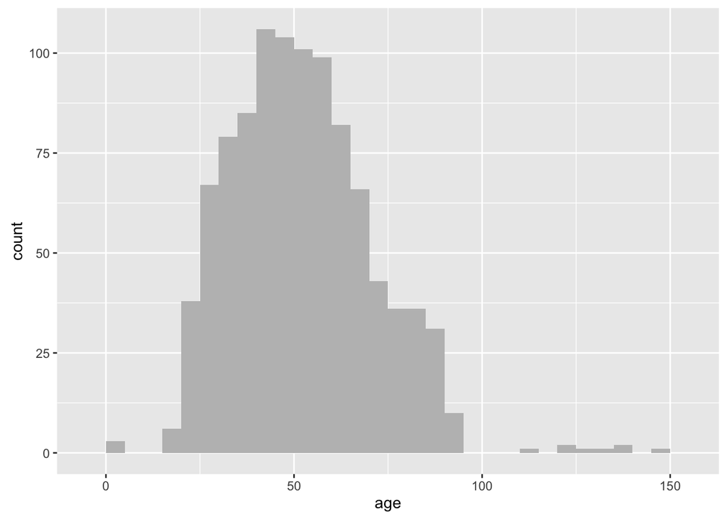

```r
# histograms
library(ggplot2)
ggplot(custdata) +
        geom_histogram(aes(x = age),
                       binwidth = 5,
                       fill = "gray")
```

## Density Plots

The primary disadvantage of histograms is that you must decide ahead of time how wide the buckets are. If the buckets are too wide, you can lose information about the shape of the distribution. If the buckets are too narrow, the histogram can look too noisy to read easily. An alternative visualization is the density plot.

You can think of a density plot as a “continuous histogram” of a variable, except the area under the density plot is equal to 1. A point on a density plot corresponds to the fraction of data (or the percentage of data, divided by 100) that takes on a particular value. This fraction is usually very small. When you look at a density plot, you’re more interested in the overall shape of the curve than in the actual values on the y-axis.

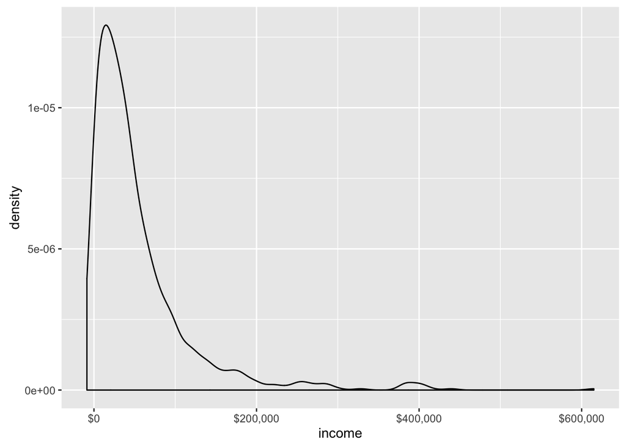

```r
library(scales)
ggplot(custdata) +
        geom_density(aes(x = income)) +
                             scale_x_continuous(labels = dollar)
```

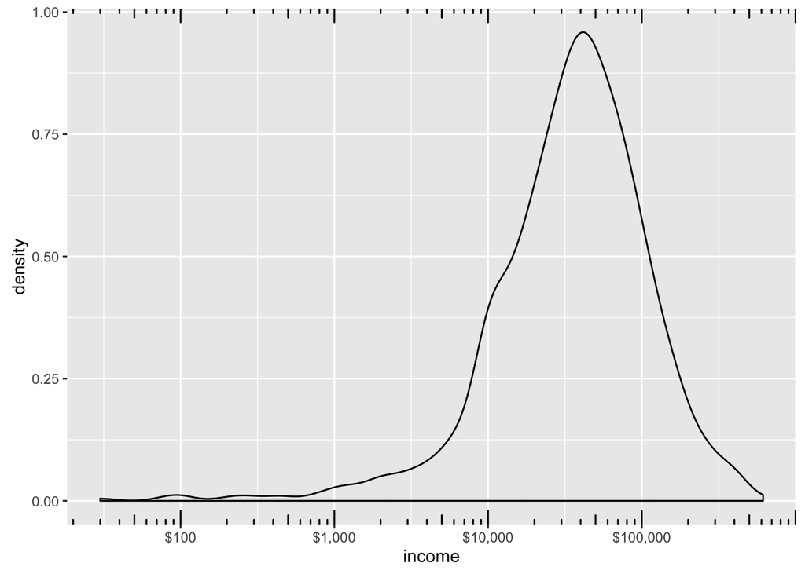

```r
# When the data range is very wide and the mass of the distribution is heavily concentrated to one side then its difficult to see the details
# of the shape

ggplot(custdata) +
        geom_density(aes(x = income)) + scale_x_log10(breaks = c(100, 1000, 10000, 100000), labels = dollar) +
        annotation_logticks(sides = "bt")
```

## Bar Charts

A bar chart is a histogram for discrete data: it records the frequency of every value of a categorical variable.

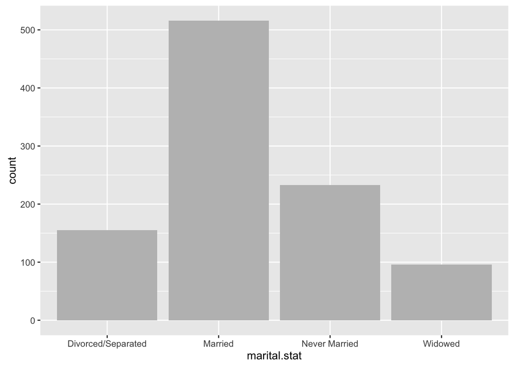

```r
# bar chart for marital status
ggplot(custdata) + geom_bar(aes(x = marital.stat), fill = "gray")
```

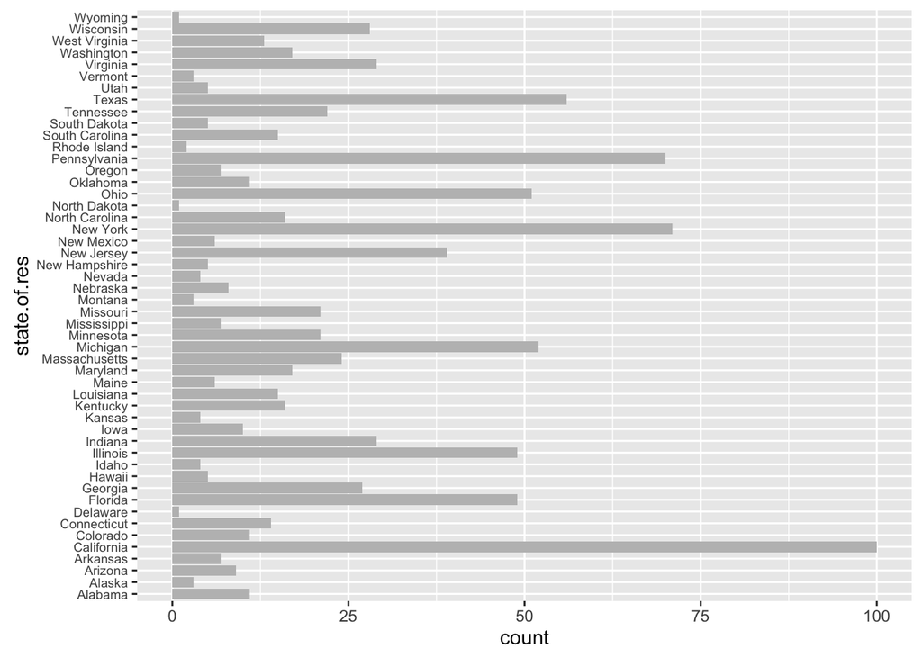

```r
# horizontal bar chart

ggplot(custdata) +
        geom_bar(aes(x = state.of.res), fill = "gray") +
        coord_flip() +
        theme(axis.text.y = element_text(size = rel(0.8)))
```

```r
# reorder to change the y-axis to sort by values
statesums <- table(custdata$state.of.res) # The table() command aggregates the data by state of residence - exactly the information the bar chart plots.
statef <- as.data.frame(statesums)
colnames(statef) <- c("state.of.res", "count") # change the column names
summary(statef)
```

```
##      state.of.res     count
##  Alabama   : 1    Min.   :  1.00
##  Alaska    : 1    1st Qu.:  5.00
##  Arizona   : 1    Median : 12.00
##  Arkansas  : 1    Mean   : 20.00
##  California: 1    3rd Qu.: 26.25
##  Colorado  : 1    Max.   :100.00
##  (Other)   :44
```

```r
# Use the reorder() function to set the state.of.res variable to be count ordered. Use the transform() function to apply the transformation
# to the state.of.res data frame.
statef <- transform(statef,
                    state.of.res = reorder(state.of.res, count))
summary(statef)
```

```
##        state.of.res     count
##  Delaware    : 1    Min.   :  1.00
##  North Dakota: 1    1st Qu.:  5.00
##  Wyoming     : 1    Median : 12.00
##  Rhode Island: 1    Mean   : 20.00
##  Alaska      : 1    3rd Qu.: 26.25
##  Montana     : 1    Max.   :100.00
##  (Other)     :44
```

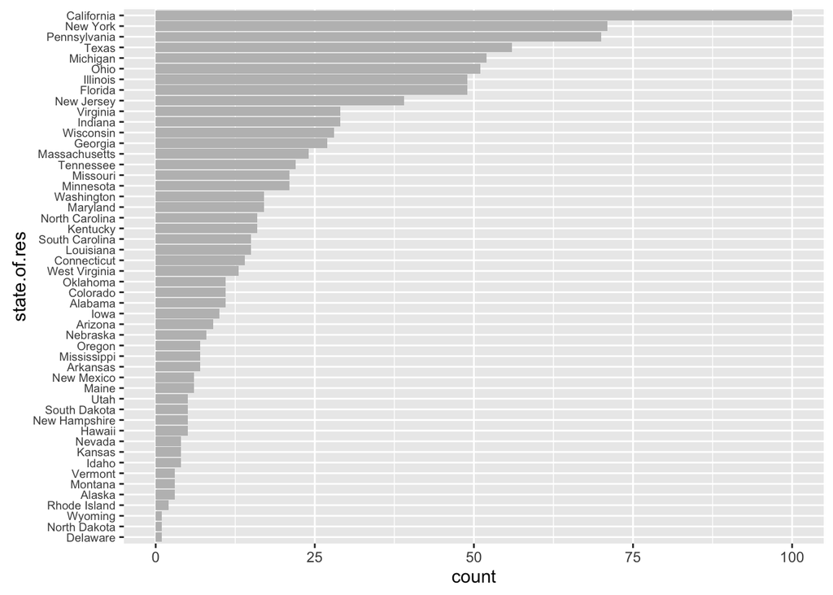

```r
ggplot(statef) + geom_bar(aes(x = state.of.res, y = count), stat = "identity", fill = "gray") +
        coord_flip() +
        theme(axis.text.y = element_text(size = rel(0.8)))
```

## Line Charts and Scatter Plots

- Line plots work best when the relationship between two variables is relatively clean
- When the data is not so cleanly related, line plots aren’t as useful; you’ll want to use the scatter plot instead

```r
custdata2 <- subset(custdata, (custdata$age > 0 & custdata$age < 100
                               & custdata$income > 0))

cor(custdata2$age, custdata2$income)
```

```
## [1] -0.02240845
```

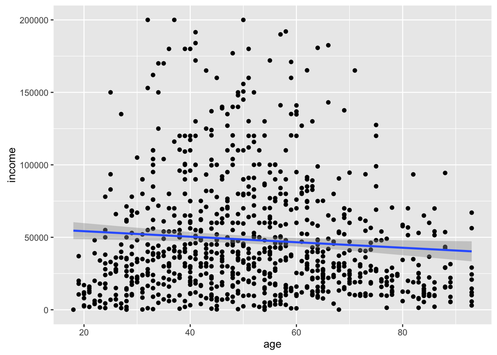

```r
# Lets try scatter plot
ggplot(custdata2, aes(x = age, y = income)) + # x is age and y is income
        geom_point() + # a scatter plot
        ylim(0, 200000) + # ylimits range from 0 to 200,000
        stat_smooth(method = "lm") # create linear fit
```

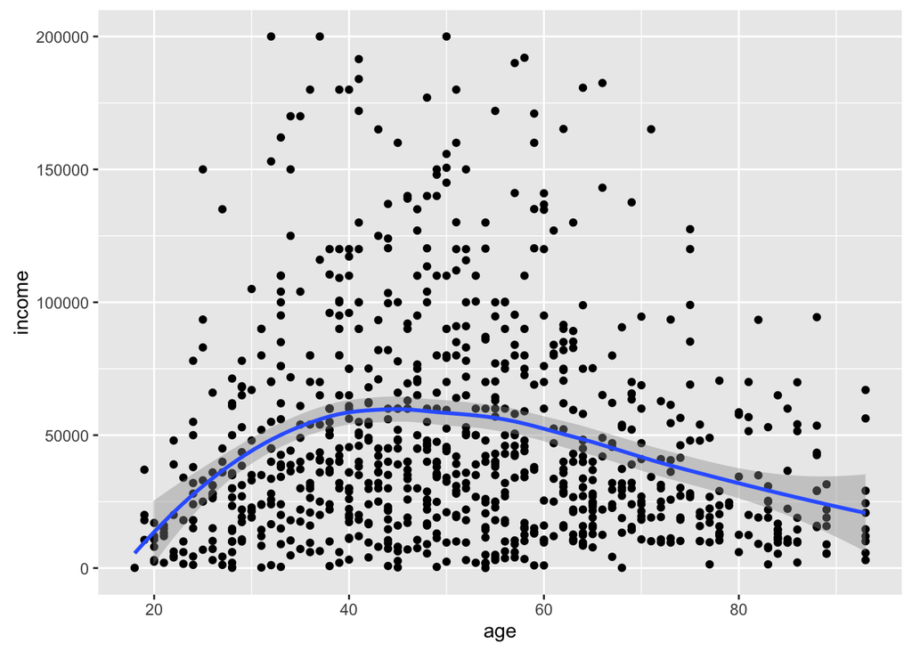

```r
# In this case, the linear fit doesn’t really capture the shape of the data.
# You can better capture the shape by instead plotting a smoothing curve through the data


# Scatter plot with curved smooth
ggplot(custdata2, aes(x = age, y = income)) + # x is age and y is income
        geom_point() + # a scatter plot
        ylim(0, 200000) + # ylimits range from 0 to 200,000
        stat_smooth() # create a smooth fit using loess function
```

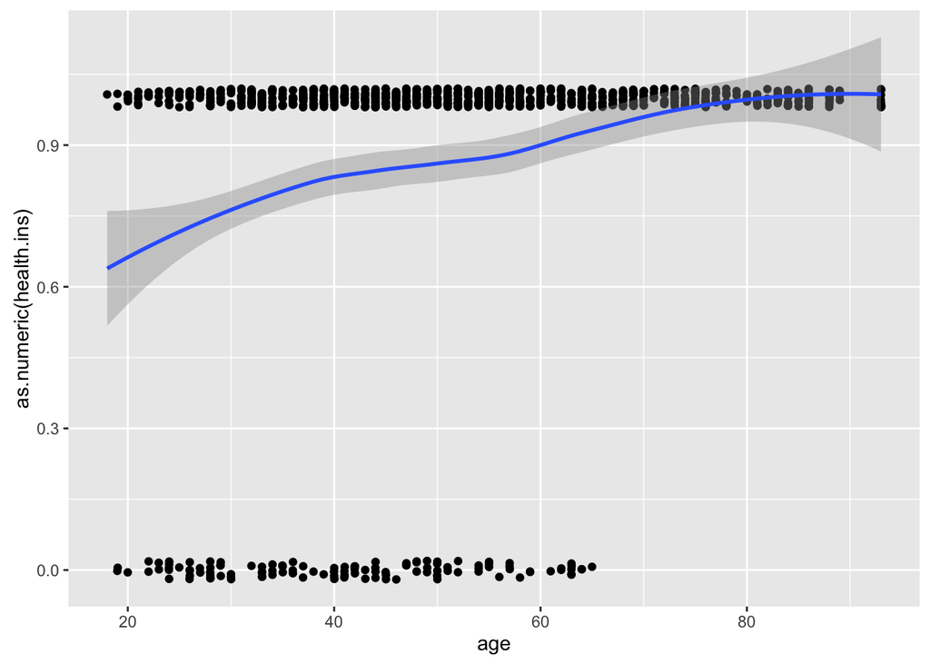

```r
# A scatter plot with a smoothing curve also makes a good visualization of the relationship between a continuous variable and a Boolean.

# Scatter plot with smoothing
ggplot(custdata2, aes(x = age, y = as.numeric(health.ins))) +
        geom_point(position = position_jitter(height = 0.05, width = 0.05)) +
        geom_smooth()
```

In our health insurance examples, the dataset is small enough that the scatter plots that you’ve created are still legible. If the dataset were a hundred times bigger, there would be so many points that they would begin to plot on top of each other; the scatter plot would turn into an illegible smear. In high-volume situations like this, try an aggregated plot, like a hexbin plot.